# R Notebook

```r
library(tidyverse)
library(ggplot2)
data(msleep)
library(infer)
```

Question 1. Explore the dataset and familiarise yourself with it.

```r
glimpse(msleep)
```

```
Rows: 83
Columns: 11
$ name         <chr> "Cheetah", "Owl monkey", "Mountain beaver", "Greater short-tailed shrew", "Cow", "Three-toed sloth", "Northern fur seal", "Vesper mouse", "Dog", "…
$ genus        <chr> "Acinonyx", "Aotus", "Aplodontia", "Blarina", "Bos", "Bradypus", "Callorhinus", "Calomys", "Canis", "Capreolus", "Capri", "Cavis", "Cercopithecus"…
$ vore         <chr> "carni", "omni", "herbi", "omni", "herbi", "herbi", "carni", NA, "carni", "herbi", "herbi", "herbi", "omni", "herbi", "omni", "omni", "omni", "car…
$ order        <chr> "Carnivora", "Primates", "Rodentia", "Soricomorpha", "Artiodactyla", "Pilosa", "Carnivora", "Rodentia", "Carnivora", "Artiodactyla", "Artiodactyla…
$ conservation <chr> "lc", NA, "nt", "lc", "domesticated", NA, "vu", NA, "domesticated", "lc", "lc", "domesticated", "lc", "domesticated", "lc", NA, "lc", "lc", "lc", …
$ sleep_total  <dbl> 12.1, 17.0, 14.4, 14.9, 4.0, 14.4, 8.7, 7.0, 10.1, 3.0, 5.3, 9.4, 10.0, 12.5, 10.3, 8.3, 9.1, 17.4, 5.3, 18.0, 3.9, 19.7, 2.9, 3.1, 10.1, 10.9, 14…
$ sleep_rem    <dbl> NA, 1.8, 2.4, 2.3, 0.7, 2.2, 1.4, NA, 2.9, NA, 0.6, 0.8, 0.7, 1.5, 2.2, 2.0, 1.4, 3.1, 0.5, 4.9, NA, 3.9, 0.6, 0.4, 3.5, 1.1, NA, 3.2, 1.1, 0.4, 0…
$ sleep_cycle  <dbl> NA, NA, NA, 0.1333333, 0.6666667, 0.7666667, 0.3833333, NA, 0.3333333, NA, NA, 0.2166667, NA, 0.1166667, NA, NA, 0.1500000, 0.3833333, NA, 0.33333…
$ awake        <dbl> 11.90, 7.00, 9.60, 9.10, 20.00, 9.60, 15.30, 17.00, 13.90, 21.00, 18.70, 14.60, 14.00, 11.50, 13.70, 15.70, 14.90, 6.60, 18.70, 6.00, 20.10, 4.30,…
$ brainwt      <dbl> NA, 0.01550, NA, 0.00029, 0.42300, NA, NA, NA, 0.07000, 0.09820, 0.11500, 0.00550, NA, 0.00640, 0.00100, 0.00660, 0.00014, 0.01080, 0.01230, 0.006…
$ bodywt       <dbl> 50.000, 0.480, 1.350, 0.019, 600.000, 3.850, 20.490, 0.045, 14.000, 14.800, 33.500, 0.728, 4.750, 0.420, 0.060, 1.000, 0.005, 3.500, 2.950, 1.700,…
```

```r
msleep
```

| name | genus | vore | order | conservation | sleep_total | sleep_rem | sleep_cycle | awake | brainwt | bodywt |
| --- | --- | --- | --- | --- | --- | --- | --- | --- | --- | --- |
| Cheetah | Acinonyx | carni | Carnivora | lc | 12.1 | NA | NA | 11.90 | NA | 50.000 |
| Owl monkey | Aotus | omni | Primates | NA | 17.0 | 1.8 | NA | 7.00 | 0.01550 | 0.480 |
| Mountain beaver | Aplodontia | herbi | Rodentia | nt | 14.4 | 2.4 | NA | 9.60 | NA | 1.350 |
| Greater short-tailed shrew | Blarina | omni | Soricomorpha | lc | 14.9 | 2.3 | 0.1333333 | 9.10 | 0.00029 | 0.019 |
| Cow | Bos | herbi | Artiodactyla | domesticated | 4.0 | 0.7 | 0.6666667 | 20.00 | 0.42300 | 600.000 |
| Three-toed sloth | Bradypus | herbi | Pilosa | NA | 14.4 | 2.2 | 0.7666667 | 9.60 | NA | 3.850 |
| Northern fur seal | Callorhinus | carni | Carnivora | vu | 8.7 | 1.4 | 0.3833333 | 15.30 | NA | 20.490 |
| Vesper mouse | Calomys | NA | Rodentia | NA | 7.0 | NA | NA | 17.00 | NA | 0.045 |
| Dog | Canis | carni | Carnivora | domesticated | 10.1 | 2.9 | 0.3333333 | 13.90 | 0.07000 | 14.000 |
| Roe deer | Capreolus | herbi | Artiodactyla | lc | 3.0 | NA | NA | 21.00 | 0.09820 | 14.800 |

[output cut: 73 more lines]

Question 2. Jabberwockies sleep for around 7 hours a night, on average. Perform an appropriate statistical test to determine whether the mean sleep_total in the sampled population of animal types differs from the typical value for jabberwockies. H0 - Jabberwockies have the same mean sleep length as other animals in the set. H1 - abberwockies don’t have the same mean sleep length as other animals in the set.

```r
observed_statistic <- msleep %>%
  summarise(mean_sleep = mean(sleep_total)) %>%
  pull(mean_sleep)
```

```r
null_distribution <- msleep %>%
  specify(response = sleep_total) %>%
  hypothesize(null = "point", mu = observed_statistic) %>%
  generate(reps = 10000, type = "bootstrap") %>%
  calculate(stat = "mean")
```

```r
get_p_value(null_distribution, obs_stat = 7, direction = "both")
```

| p_value |
| --- |
| 0 |

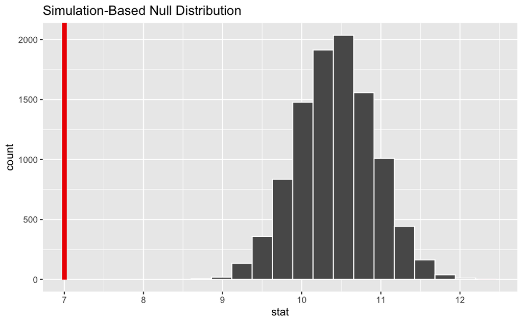

```r
null_distribution %>%
  visualise() +
  shade_p_value(obs_stat = 7, direction = "both")
```

The P valiue is 0 - we reject the null hypothesis that the Jabberwockies have the same mean sleep length as other animals in the set.

Question 3. Perform an appropriate statistical test to determine whether omnivores sleep for significantly longer than herbivores, on average

H0 - omnivores do not sleep for significantly longer than herbivores H1 - omnivores do sleep longer than herbivores

```r
null_distribution <- msleep %>%
  filter(vore %in% c("herbi","omni")) %>%
  specify(sleep_total ~ vore) %>%
  hypothesize(null = "independence") %>%
  generate(reps = 1000, type = "permute") %>%
  calculate(stat = "diff in means", order = c("omni", "herbi"))
```

[output not shown]

```r
null_distribution %>%
  get_p_value(obs_stat = observed_statistic, direction = "both")
```

[output not shown]

Question 4. Perform an appropriate statistical test to determine whether the proportion of domesticated animal types in the population of animal types is greater than 5% .

```r
counts <-  msleep %>%
  mutate(conservation = case_when(
    conservation == "domesticated" ~ "domesticated",
    TRUE ~ "undomesticated"
  )) %>%
  count(conservation)

observed_statistic <- counts$n[[1]]/(counts$n[[2]] + counts$n[[1]])


null_distribution <- msleep %>%
  mutate(conservation = case_when(
    conservation == "domesticated" ~ "domesticated",
    TRUE ~ "undomesticated"
  )) %>%
  specify(response = conservation, success = "domesticated") %>%
  hypothesize(null = "point", p = 0.05) %>%
  generate(reps = 10000, type = "draw") %>%
  calculate(stat = "prop")

null_distribution %>%
  get_p_value(obs_stat = observed_statistic, direction = "both")
```

| p_value |
| --- |
| 0.0152 |

p value is 0.015, which means we can reject our null hypothesis that the proportion of domesticated animal types in the population of animal types is not greater than 5%

For the following three business problems write out:

What kind of test you would use H0 and Ha in both mathematical notation and in words. Also state the method you would use to generate the null distribution (bootstrap, permutation or simulation).

Question 1. You work for a independent coffee shop. The boss tells you that she thinks that around 40% of people in the town (population 30,000) know of the coffee shop, but you are skeptical of the estimate. You conduct a random survey of 200 people in the town, asking if respondents are aware of your coffee shop. You want to use the sample to test the hypothesis that 40% or more of the town’s population have heard of the coffee shop.

H0 - less than 40% of people in town know the coffee shop H1 - 40% or more of people in town know the coffee shop

$$H_0 : N_k/\Sigma N < 0.40$$
$$H_1 : N_k/\Sigma N \ge 0.40$$
To generate the null distribution of this I would use a DRAW method.

Question 2. You work for a website design company and have performed an A/B test on the position of a banner on a website promoting a particular item.

A/B testing A method comparing two versions of a web page, email, flyer or other marketing device against each other to determine which version performs better. As it is essentially a controlled experiment, the design should try to ensure that the groups experiencing both versions of the marketing device are equivalent and representative of the population.

You selected five days at random last month and then randomly selected 200 of each sampled day’s users into group A and another 200 of that day’s users into group B . Group A continued to be shown the banner at the right hand side of the webpage (its usual position) while group B was shown the banner at the top of the page. You monitored each sampled user’s interactions with the website, in particular the ‘click through rate’ (CTR) on the banner, i.e. what proportion of sampled users clicked on the banner. You want to use the sampled data to test the hypothesis that website users overall are more likely to click on the banner if positioned at the top of the page

H0 - website users overall are not more likely to click on the banner if positioned at the top of the page. H0 - website users overall are more likely to click on the banner if positioned at the top of the page.

I would use bootstrapping for this option.